# Trabajo_1_R

Esteban Rojas Henao

4/4/2021

**Objetivo:** Construir una herramienta para predecir el número de hijos de una persona que viven dentro del mismo hogar en Colombia a partir de ciertas variables disponibles.

# Los datos

Se trabajará con un 3 conjuntos de datos sobre la calidad de vida en Colombia. Disponibles en

- [Características y composición del hogar](http://microdatos.dane.gov.co/index.php/catalog/678/datafile/F133)
- [Datos de la vivienda](http://microdatos.dane.gov.co/index.php/catalog/678/datafile/F137)
- [Educación](http://microdatos.dane.gov.co/index.php/catalog/678/datafile/F138)

La definición de las variables del conjunto de datos se puede encontrar en

Definición variables

La definición de las variables que se usarán es la siguiente:

**DIRECTORIO:** Identificador del hogar

**ORDEN:** Identificador de la persona dentro del hogar

**P6020:** Sexo de la persona

1. Hombre
2. Mujer

**P6040:** Edad de la persona

**relacion:** Estado sentimental de la persona

**P756:** Lugar de nacimiento de la persona

1. En este municipio
2. En otro municipio
3. En otro país

**P6080:** De acuerdo con su cultura, se reconoce como

1. Indígena
2. Gitano(a)
3. Raizal del archipiélago de San Andrés, Providencia y Santa Catalina
4. Palenquero(a) de San Basilio
5. Negro(a), mulato(a) (afrodescendiente), afrocolombiano(a)
6. Ninguno de los anteriores

**P2057:** ¿Usted se considera campesino?

1. Si
2. No
3. No informa

**satisfaccion:** Satisfacción general de la persona teniendo en cuenta vida, ingreso, salud, nivel de seguridad y trabajo/actividad

**vivienda:** Tipo de vivienda

1. Casa
2. Apartamento
3. Otro

**P8520S1:** ¿La vivienda cuenta con servicio de energía eléctrica?

1. Sí
2. No

**P8520S5:** ¿La vivienda cuenta con servicio de acueducto?

1. Sí
2. No

**P8520S3:** ¿La vivienda cuenta con servicio de alcantarillado?

1. Sí
2. No

**P8520S4:** ¿La vivienda cuenta con servicio de recolección de basuras?

1. Sí
2. No

**P6160:** ¿Sabe leer y escribir?

0. No informa
1. Sí
2. No

**P8587:** ¿Cuál es el nivel educativo más alto alcanzado?

0. No informa
1. Ninguno
2. Preescolar
3. Básica Primaria
4. Básica secundaria
5. Media
6. Técnico sin título
7. Técnico con título
8. Tecnológico sin título
9. Tecnológico con título
10. Universitario sin título
11. Universitario con título
12. Posgrado sin título
13. Posgrado con título

# Análisis descriptivo

Lectura de la base de datos:

```r
datos <- read_excel("Datos.xlsx")
datos
```

```
## # A tibble: 145,898 x 17
##    DIRECTORIO ORDEN P6020 P6040 relacion  P756 P6080 P2057 satisfaccion vivienda
##         <dbl> <dbl> <dbl> <dbl>    <dbl> <dbl> <dbl> <dbl>        <dbl>    <dbl>
##  1    7120001     1     2    44        2     1     6     2          9.6        2
##  2    7120001     2     1    48        2     2     1     2          7          2
##  3    7120002     1     1    61        6     1     5     2          6.6        1
##  4    7120002     2     2    54        6     2     5     2          6.4        1
##  5    7120002     6     1    28        1     1     5     2          5.8        1
##  6    7120002     7     2    19        1     1     5     2          7.2        1
##  7    7120002     9     1    31        4     1     5     2          7.4        1
##  8    7120005     1     1    79        6     2     6     2          6.2        1
##  9    7120006     1     2    37        5     2     6     2          5.6        2
## 10    7120007     1     1    72        5     1     5     2          8          2
## # ... with 145,888 more rows, and 7 more variables: P8520S1 <dbl>,
## #   P8520S5 <dbl>, P8520S3 <dbl>, P8520S4 <dbl>, P6160 <dbl>, P8587 <dbl>,
## #   hijos <dbl>
```

Selección de las columnas que se analizarán:

```r
datos_sel <- subset(datos,select = c('P6020', 'P6040', 'relacion', 'P756', 'P6080', 'P2057', 'satisfaccion', 'vivienda', 'P8520S1', 'P8520S5', 'P8520S3', 'P8520S4', 'P6160', 'P8587', 'hijos'))
names(datos_sel) = c('sexo', 'edad', 'relacion', 'nacimiento', 'cultura', 'campesino', 'satisfaccion', 'vivienda', 'energia', 'acueducto', 'alcantarillado', 'basura', 'leer_escribir', 'nivel_educativo', 'hijos')
```

## Medidas de localización y escala

```r
kable(summary(datos_sel),caption = "Medidas de localización")
```

Medidas de localización

|  | sexo | edad | relacion | nacimiento | cultura | campesino | satisfaccion | vivienda | energia | acueducto | alcantarillado | basura | leer_escribir | nivel_educativo | hijos |
| --- | --- | --- | --- | --- | --- | --- | --- | --- | --- | --- | --- | --- | --- | --- | --- |
|  | Min. :1.000 | Min. : 1.00 | Min. :0.00 | Min. :1.000 | Min. :1.000 | Min. :1.000 | Min. : 0.000 | Min. :1.000 | Min. :1.000 | Min. :1.000 | Min. :1.000 | Min. :1.000 | Min. :0.000 | Min. : 0.000 | Min. : 0.000 |
|  | 1st Qu.:1.000 | 1st Qu.: 33.00 | 1st Qu.:2.00 | 1st Qu.:1.000 | 1st Qu.:6.000 | 1st Qu.:1.000 | 1st Qu.: 6.600 | 1st Qu.:1.000 | 1st Qu.:1.000 | 1st Qu.:1.000 | 1st Qu.:1.000 | 1st Qu.:1.000 | 1st Qu.:1.000 | 1st Qu.: 3.000 | 1st Qu.: 0.000 |
|  | Median :2.000 | Median : 44.00 | Median :3.00 | Median :1.000 | Median :6.000 | Median :1.000 | Median : 7.600 | Median :1.000 | Median :1.000 | Median :1.000 | Median :2.000 | Median :1.000 | Median :1.000 | Median : 4.000 | Median : 1.000 |
|  | Mean :1.531 | Mean : 46.07 | Mean :3.62 | Mean :1.459 | Mean :5.386 | Mean :1.409 | Mean : 7.477 | Mean :1.266 | Mean :1.052 | Mean :1.284 | Mean :1.502 | Mean :1.363 | Mean :1.084 | Mean : 4.355 | Mean : 1.341 |
|  | 3rd Qu.:2.000 | 3rd Qu.: 58.00 | 3rd Qu.:5.00 | 3rd Qu.:2.000 | 3rd Qu.:6.000 | 3rd Qu.:2.000 | 3rd Qu.: 8.600 | 3rd Qu.:1.000 | 3rd Qu.:1.000 | 3rd Qu.:2.000 | 3rd Qu.:2.000 | 3rd Qu.:2.000 | 3rd Qu.:1.000 | 3rd Qu.: 5.000 | 3rd Qu.: 2.000 |
|  | Max. :2.000 | Max. :117.00 | Max. :6.00 | Max. :3.000 | Max. :6.000 | Max. :3.000 | Max. :10.000 | Max. :3.000 | Max. :2.000 | Max. :2.000 | Max. :2.000 | Max. :2.000 | Max. :2.000 | Max. :13.000 | Max. :11.000 |

```r
kable(t(apply(datos_sel,2,sd)),caption = "Desviaciones estándar")
```

Desviaciones estándar

| sexo | edad | relacion | nacimiento | cultura | campesino | satisfaccion | vivienda | energia | acueducto | alcantarillado | basura | leer_escribir | nivel_educativo | hijos |
| --- | --- | --- | --- | --- | --- | --- | --- | --- | --- | --- | --- | --- | --- | --- |
| 0.4990337 | 16.71085 | 1.704438 | 0.5533205 | 1.514569 | 0.5019355 | 1.51516 | 0.5304444 | 0.2222669 | 0.4507739 | 0.499999 | 0.4809777 | 0.2768512 | 2.669742 | 1.16101 |

## Gráficos descriptivos

### Gráficos de barras

#### Situación sentimental, sexo, lugar de nacimiento, cultura, si se considera campesino y tipo de vivienda

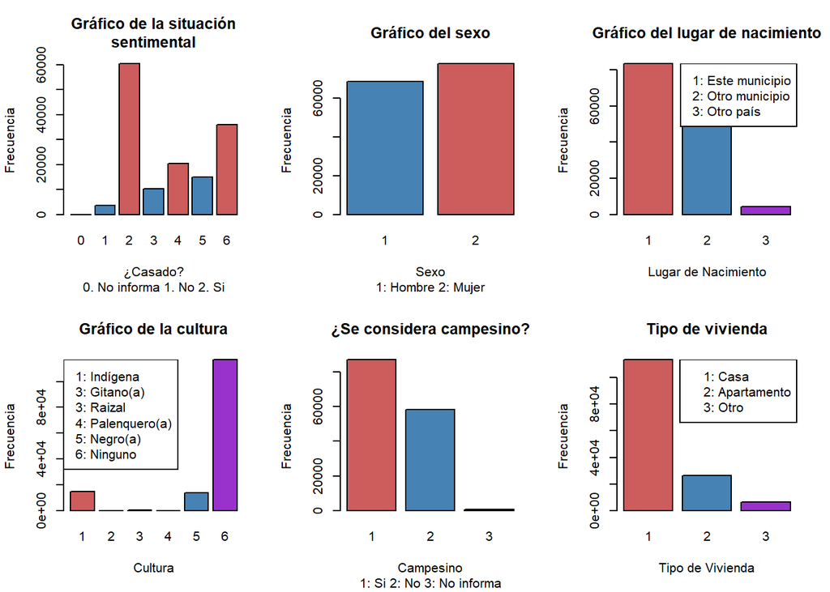

```r
par(mfrow=c(2, 3))

barplot(table(datos_sel$relacion), xlab='¿Casado?', ylab='Frecuencia', main='Gráfico de la situación\nsentimental', col=c('indianred', 'steelblue'), sub='0. No informa 1. No 2. Si')

barplot(table(datos_sel$sexo), xlab='Sexo', ylab='Frecuencia', main='Gráfico del sexo', sub='1: Hombre 2: Mujer', col=c('steelblue', 'indianred'))

barplot(table(datos_sel$nacimiento), xlab='Lugar de Nacimiento', ylab='Frecuencia', main='Gráfico del lugar de nacimiento', col=c('indianred', 'steelblue', 'darkorchid'))
legend('topright', legend=c('1: Este municipio', '2: Otro municipio', '3: Otro país'), x.intersp=0)

barplot(table(datos_sel$cultura), xlab='Cultura', ylab='Frecuencia', main='Gráfico de la cultura', col=c('indianred', 'steelblue', 'darkorchid'))
legend('topleft', legend=c('1: Indígena', '3: Gitano(a)', '3: Raizal', '4: Palenquero(a)', '5: Negro(a)', '6: Ninguno'), x.intersp=0)

barplot(table(datos_sel$campesino), xlab='Campesino', ylab='Frecuencia', main='¿Se considera campesino?', col=c('indianred', 'steelblue', 'darkorchid'), sub='1: Si 2: No 3: No informa')

barplot(table(datos_sel$vivienda), xlab='Tipo de Vivienda', ylab='Frecuencia', main='Tipo de vivienda', col=c('indianred', 'steelblue', 'darkorchid'))
legend('topright', legend=c('1: Casa', '2: Apartamento', '3: Otro'))
```

#### Servicios que tiene el hogar (Energía, Acueducto, Alcantarillado, Recolección de basuras)

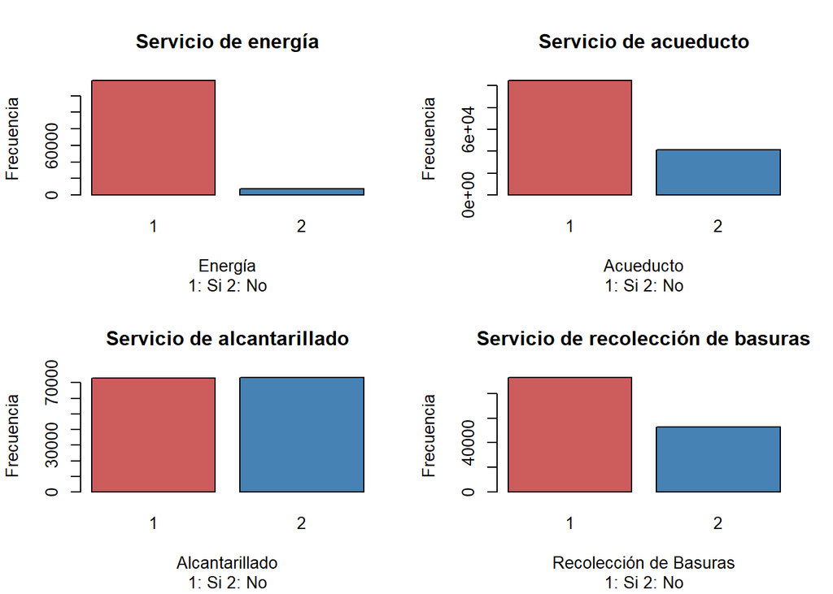

```r
par(mfrow=c(2, 2))

barplot(table(datos_sel$energia), xlab='Energía', ylab='Frecuencia', main='Servicio de energía', col=c('indianred', 'steelblue', 'darkorchid'), sub='1: Si 2: No')

barplot(table(datos_sel$acueducto), xlab='Acueducto', ylab='Frecuencia', main='Servicio de acueducto', col=c('indianred', 'steelblue', 'darkorchid'), sub='1: Si 2: No')

barplot(table(datos_sel$alcantarillado), xlab='Alcantarillado', ylab='Frecuencia', main='Servicio de alcantarillado', col=c('indianred', 'steelblue', 'darkorchid'), sub='1: Si 2: No')

barplot(table(datos_sel$basura), xlab='Recolección de Basuras', ylab='Frecuencia', main='Servicio de recolección de basuras', col=c('indianred', 'steelblue', 'darkorchid'), sub='1: Si 2: No')
```

#### Educación: Sabe leer y escribir

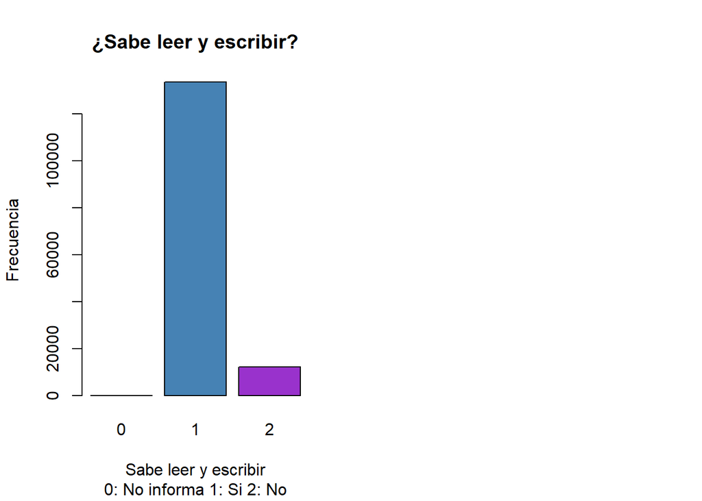

```r
par(mfrow=c(1, 2))
barplot(table(datos_sel$leer_escribir), xlab='Sabe leer y escribir', ylab='Frecuencia', main='¿Sabe leer y escribir?', col=c('indianred', 'steelblue', 'darkorchid'), sub='0: No informa 1: Si 2: No')
```

### Histogramas

#### Edad, Satisfacción con la vida, nivel educativo y número de hijos

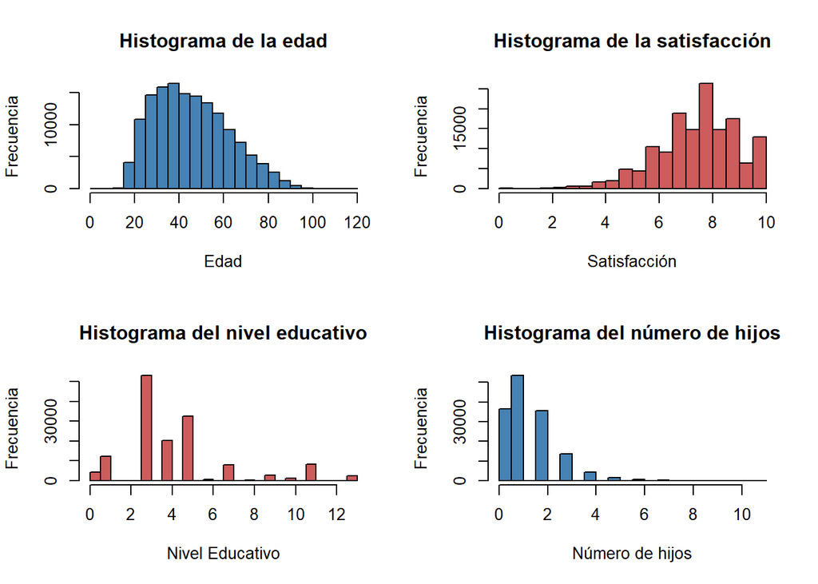

```r
par(mfrow=c(2, 2))

hist(datos_sel$edad, xlab='Edad', ylab='Frecuencia', main='Histograma de la edad', col='steelblue')

hist(datos_sel$satisfaccion, xlab='Satisfacción', ylab='Frecuencia', main='Histograma de la satisfacción', col='indianred')

hist(datos_sel$nivel_educativo, xlab='Nivel Educativo', ylab='Frecuencia', main='Histograma del nivel educativo', col='indianred')

hist(datos_sel$hijos, xlab='Número de hijos', ylab='Frecuencia', main='Histograma del número de hijos', col='steelblue')
```

## Exploración de relaciones

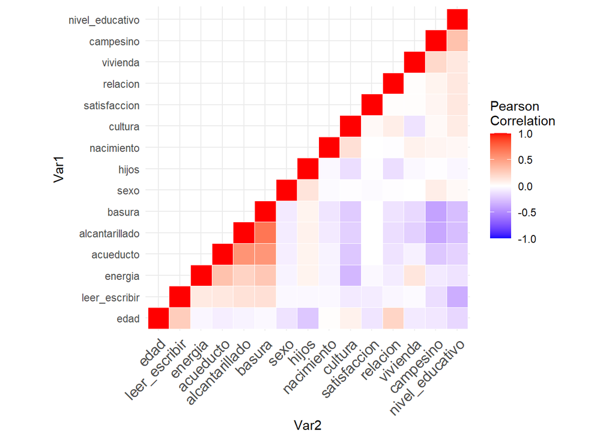

```r
cormat <- round(cor(na.omit(datos_sel)),2) # Matriz de correlación

# Diagonal inferior de la matriz
get_lower_tri<-function(cormat){
  cormat[upper.tri(cormat)] <- NA
  return(cormat)
}

# Diagonal superior de la matriz
get_upper_tri <- function(cormat){
  cormat[lower.tri(cormat)]<- NA
  return(cormat)
}

upper_tri <- get_upper_tri(cormat)

melted_cormat <- melt(upper_tri, na.rm = TRUE)

reorder_cormat <- function(cormat){
  # Usa la correlación entre variables como la distancia
  dd <- as.dist((1-cormat)/2)
  hc <- hclust(dd)
  cormat <-cormat[hc$order, hc$order]
}

# Reordena la matriz con los colores
cormat <- reorder_cormat(cormat)
upper_tri <- get_upper_tri(cormat)

melted_cormat <- melt(upper_tri, na.rm = TRUE)

ggheatmap <- ggplot(melted_cormat, aes(Var2, Var1, fill = value))+
 geom_tile(color = "white")+
 scale_fill_gradient2(low = "blue", high = "red", mid = "white",
   midpoint = 0, limit = c(-1,1), space = "Lab",
    name="Pearson\nCorrelation") +
  theme_minimal()+
 theme(axis.text.x = element_text(angle = 45, vjust = 1,
    size = 12, hjust = 1))+
 coord_fixed()
# Print the heatmap
print(ggheatmap)
```

### Conclusión del análisis descriptivo

Se aprecian algunas relaciones entre las variables de la base de datos y la variable respuesta, sin embargo ninguna tiene una alta correlación con la variable de respuesta T-T

## Modelamiento

# Acá termina, la creación del modelo no fue realizada